# Act report

In this project, we wrangled, analysed and visualised the dataset of the tweet archive of Twitter user [@dog_rates](https://twitter.com/dog_rates), also known as WeRateDogs. WeRateDogs is a Twitter account that rates people's dogs with a humorous comment about the dog.

> First of all, 3 datasets have been gathered to perform a better analysis, The WeRateDogs Twitter archive, The tweet image predictions and Additional data from the Twitter API.  
> For the assessment part, the two types have been required. For visual assessment, I used Sublime and Google Sheets, along with the non directed visuel assessment through juputer notebook to detect pertinent issues. For programmatic assessment, I used pandas Methods and functions to perform directed and non directed methods assessment. I detected 8 quality issues and two tidinrss issues.  
> For the cleaning part, I used the **define, code, and test** steps of the cleaning process. I utilized the most common cleaning functions and methods in the pandas library to clean the eight quality issues and two tidiness issues identified in the previous step Assessing Data.  
> After the gatherin, assessing and cleaning processes, I had a tidy and high quality data.\

Then, I performed the analysis and the visualization and generated a few insights.

### Correlation between favorite count and retweet count

For the following chart, I tried to identify if there is a correlation between the favorite count and the retweet count.

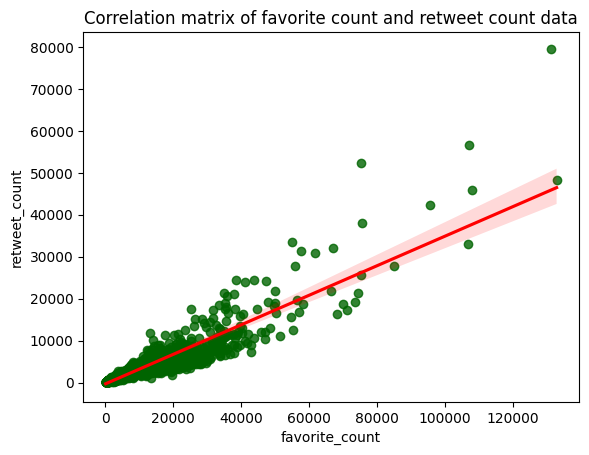

> The above scatter plot shows a positive correlation between the favorite count and the retweet count. Which means that the more the gog is liked, the more the tweet will be retweeted and vice versa.

### Favorite dog stages per rating

Here, I wanted to categorise the dog stages per their rating numerator and to identify which dog stage with a specific rating have been liked the most.

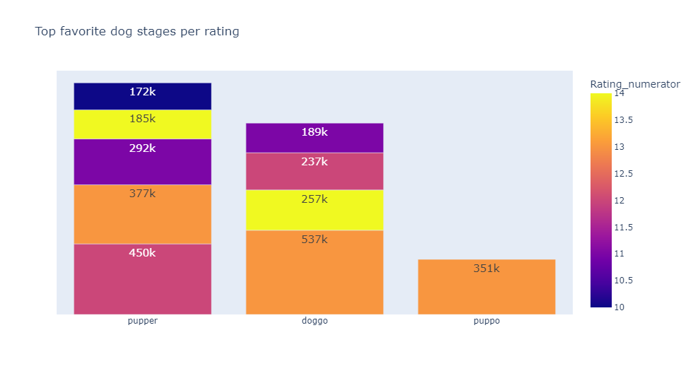

> It can be seen from the above bar plot, that the most rated dog stage is the **doggo** stage with the rating numerator of 13 with 537K favorite counts. Followed by, the **pupper** dog stage with the rating numerator of 12 and a favorite count of 450K.

### Top retweeted dogs names per rating

For this last part, I wanted to identify the dog with the higher retweeted count, and to know its rating and name.

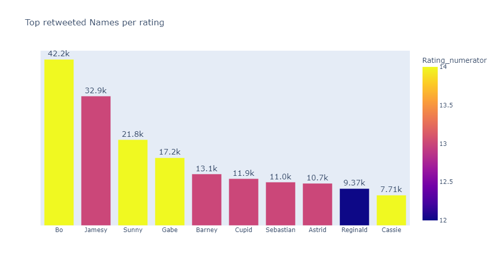

> As shown from the chart above, the most retweeted dog is **BO** with 42.2K retweets and a rating of 14. Followed by, **Jamesy** with 32.9K retweets and a rating of 13.

#### And the winner is:

```python
from IPython.display import Image
Image(url= "https://pbs.twimg.com/media/C12whDoVEAALRxa.jpg", width=500, height=300)
```

[figure not shown]